# The analysis of the activity data

2024/11/06

By Satoshi Ohnishi

### 1. Read the activity data

Load the necessary libraries and read the activity data.

```r
library(dplyr)
```

```r
library(ggplot2)

# read activity.csv
activity <- read.csv("activity.csv")
head(activity)
```

```
##   steps       date interval
## 1    NA 2012-10-01        0
## 2    NA 2012-10-01        5
## 3    NA 2012-10-01       10
## 4    NA 2012-10-01       15
## 5    NA 2012-10-01       20
## 6    NA 2012-10-01       25
```

### 2. Caliculate total number of steps taken per day

Now, Let us calculate the total number of steps taken per day.

```r
total_steps <- aggregate(steps ~ date, data = activity, sum)
total_steps
```

```
##          date steps
## 1  2012-10-02   126
## 2  2012-10-03 11352
## 3  2012-10-04 12116
## 4  2012-10-05 13294
## 5  2012-10-06 15420
## 6  2012-10-07 11015
## 7  2012-10-09 12811
## 8  2012-10-10  9900
## 9  2012-10-11 10304
## 10 2012-10-12 17382
## 11 2012-10-13 12426
## 12 2012-10-14 15098
## 13 2012-10-15 10139
## 14 2012-10-16 15084
```

[output cut: 39 more lines]

### 3. make histogram of the total number of steps taken each day

How distributed the total number of steps taken each day is?

Let us make a histogram of the total number of steps taken each day.

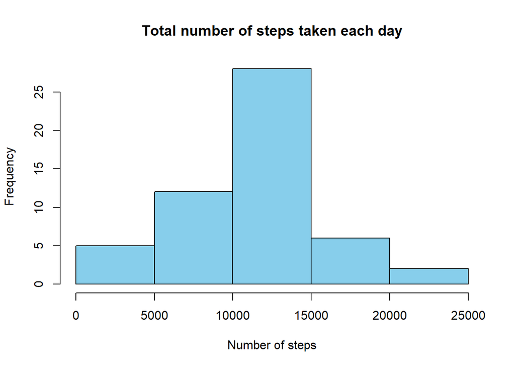

```r
hist(total_steps$steps,
     main = "Total number of steps taken each day",
     xlab = "Number of steps",
     ylab = "Frequency", col = "skyblue")
```

```r
# save the plot into 'figure' directory
dev.copy(png, file = "figure/histogram1.png")
```

### 4. Calculate the mean and median of the total number of steps taken per day

What is the mean and median of the total number of steps taken per day?

```r
#Calculate the mean and median of the total number of steps taken per day
mean_steps <- mean(total_steps$steps, na.rm = TRUE)
median_steps <- median(total_steps$steps, na.rm = TRUE)

# print mean
print(mean_steps)
```

```
## [1] 10766.19
```

```r
# print median
print(median_steps)
```

```
## [1] 10765
```

### 5. Time series plot of the average number of steps taken

Now, let us look at the time series plot of the average number of steps taken, averaged across all days.

```
## No summary function supplied, defaulting to `mean_se()`
```

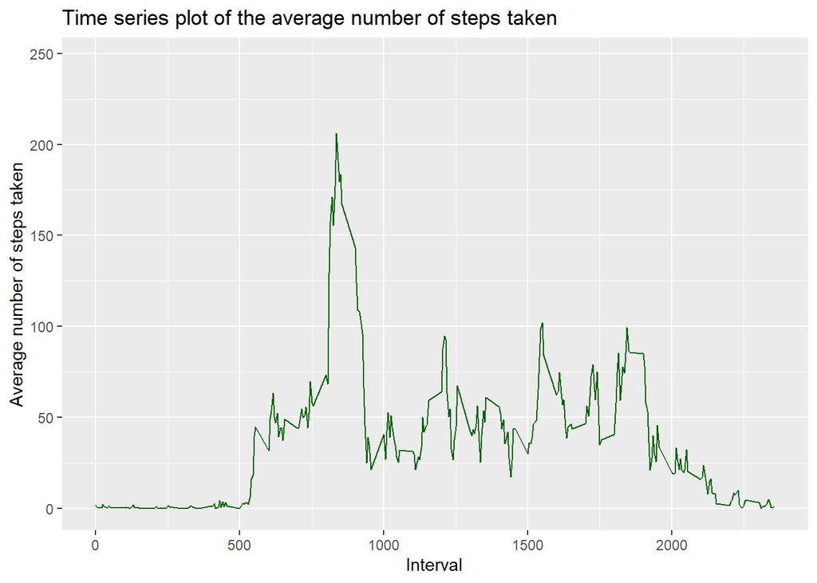

```r
# Make time series plot of the 5-minute interval and the average number of steps taken, averaged across all days
ggplot(data = activity, aes(x = interval, y = steps)) +
  geom_line(stat = "summary", fun.y = "mean", col = "darkgreen") +
  labs(title = "Time series plot of the average number of steps taken",
       x = "Interval",
       y = "Average number of steps taken")
```

```r
# Save the plot into 'figure' directory
dev.copy(png, file = "figure/timeseries.png")
```

### 6. The maximum number of steps taken in 5-minute interval

Which 5-minute interval, on average across all the days in the dataset, contains the maximum number of steps?

```r
# Which 5-minute interval, on average across all the days in the dataset, contains the maximum number of steps?
max_interval <- activity %>%
  group_by(interval) %>%
  summarise(mean_steps = mean(steps, na.rm = TRUE)) %>%
  filter(mean_steps == max(mean_steps))

print(max_interval)
```

```
## # A tibble: 1 × 2
##   interval mean_steps
##      <int>      <dbl>
## 1      835       206.
```

### 7. Imputing missing values and make histogram of the total number of steps taken each day after missing values are filled in

I think that missing values should be filled in with the 0 value.

Because if fill in with the mean or median value, the distribution of the data becomes bigger than the original data.

Therefore, I will fill in the missing values with 0.

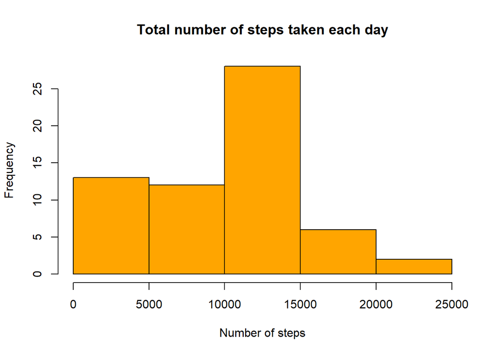

```r
# Fill in the missing values with 0
activity_imputed <- activity[is.na(activity$steps), "steps"] <- 0
# Calculate the total number of steps taken per day
total_steps_imputed <- aggregate(steps ~ date, data = activity, sum)

hist(total_steps_imputed$steps,
     main = "Total number of steps taken each day",
     xlab = "Number of steps",
     ylab = "Frequency", col = "orange")
```

```r
# save the plot into 'figure' directory
dev.copy(png, file = "figure/histogram2.png")
```

```r
# Calculate the mean and median of the total number of steps taken per day
mean_steps_imputed <- mean(total_steps_imputed$steps, na.rm = TRUE)
median_steps_imputed <- median(total_steps_imputed$steps, na.rm = TRUE)
print(mean_steps_imputed)
```

```
## [1] 9354.23
```

```r
print(median_steps_imputed)
```

```
## [1] 10395
```

### 8. Are there differences in activity patterns between weekdays and weekends?

How different are the activity patterns between weekdays and weekends?

Let us make a panel plot containing a time series plot of the 5-minute interval and the average number of steps taken, averaged across all weekday days or weekend days.

```
## No summary function supplied, defaulting to `mean_se()`
## No summary function supplied, defaulting to `mean_se()`
```

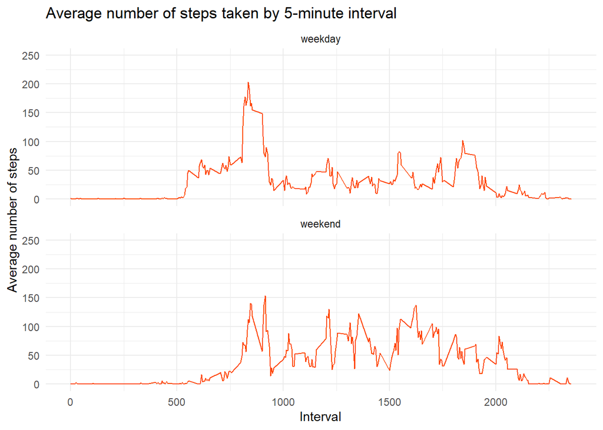

```r
# Create new column "weekday" sunday and saturday is weekend, other days are weekday
activity$date <- as.Date(activity$date)
activity$weekday <- weekdays(activity$date)
activity$weekday <- ifelse(activity$weekday == "土曜日" | activity$weekday == "日曜日", "weekend", "weekday")

# Make 2 panel plot containing a time series plot of the 5-minute interval and the average number of steps taken, averaged across all weekday days or weekend days
# weekday color is red, weekend color is blue
ggplot(data = activity, aes(x = interval, y = steps)) +
  geom_line(stat = "summary", fun.y = "mean", color = "orangered") +
  facet_wrap(~ weekday, ncol = 1, nrow = 2) +
  labs(title = "Average number of steps taken by 5-minute interval",
       x = "Interval",
       y = "Average number of steps") +
  theme_minimal()
```

```r
# Save the plot into 'figure' directory
dev.copy(png, file = "figure/panelplot.png")
```

### 9. Conclusion

In the weekday, the number of steps taken is high in the morning.

I think that the handling of missing values is important.

In this analysis, I filled in the missing values with 0.

But it may be better to fill in with the mean or median value.

I believe that the handling of missing values changes the distribution of the data and results and conclusions may change.